# Mega Awesome Beer Corp. (MABco) Case Study

Data Busters Inc. (K Henley, G Lane, J McDaniel)

October 19, 2017

Mega Awesome Beer Corp. (MABco), has commissioned Data Busters, Inc.(DBI) to examine data sets they have provided, with the purpose of answering some key questions and findings that should be derived directly from the data provided. These are the results.

Two data sets were provided by MABco and used by DBI to provide the findings below. One data set provides background on the beer offerings currently in production at MABco, and the other provides brewery data where each beer is produced. We’ve read the raw data into our systems for analysis.

```r
BeerData <- read.csv2(file="C:/Users/henlek1/Desktop/Beers.csv", header=TRUE, sep=",", col.name=c("Name", "BeerID", "ABV", "IBU", "BreweryID", "Style", "Ounces"))

BrewiesData <- read.csv2(file="C:/Users/henlek1/Desktop/Breweries.csv", header=TRUE, sep=",", col.name=c("BreweryID", "BreweryName", "City", "State"))
```

Below is the summary for both data sets. As you can see the data provided is organized into 2410 types of beer, and between the two sets of data we have 11 measurable variables to work with. We will walk you through the results below, and provide you with the background necessary to understand the context behind our findings, and hopefully answer all of your questions.

```r
summary (BeerData)
```

```
##                      Name          BeerID            ABV
##  Nonstop Hef Hop       :  12   Min.   :   1.0   0.05   : 215
##  Dale's Pale Ale       :   6   1st Qu.: 808.2   0.055  : 158
##  Oktoberfest           :   6   Median :1453.5   0.06   : 125
##  Longboard Island Lager:   4   Mean   :1431.1   0.065  : 123
##  1327 Pod's ESB        :   3   3rd Qu.:2075.8   0.052  : 107
##  Boston Lager          :   3   Max.   :2692.0   0.07   :  92
##  (Other)               :2376                    (Other):1590
##       IBU           BreweryID                                Style
##  Min.   :  4.00   Min.   :  1.0   American IPA                  : 424
##  1st Qu.: 21.00   1st Qu.: 94.0   American Pale Ale (APA)       : 245
##  Median : 35.00   Median :206.0   American Amber / Red Ale      : 133
##  Mean   : 42.71   Mean   :232.7   American Blonde Ale           : 108
##  3rd Qu.: 64.00   3rd Qu.:367.0   American Double / Imperial IPA: 105
##  Max.   :138.00   Max.   :558.0   American Pale Wheat Ale       :  97
##  NA's   :1005                     (Other)                       :1298
##   Ounces
##  12  :1525
##  16  : 841
##  16.9:   1
##  19.2:  15
##  24  :  22
##  32  :   5
##  8.4 :   1
```

```r
str(BeerData)
```

```
## 'data.frame':    2410 obs. of  7 variables:
##  $ Name     : Factor w/ 2305 levels "#001 Golden Amber Lager",..: 1638 577 1705 1842 1819 268 1160 758 1093 486 ...
##  $ BeerID   : int  1436 2265 2264 2263 2262 2261 2260 2259 2258 2131 ...
##  $ ABV      : Factor w/ 75 levels "","0.001","0.027",..: 21 37 42 61 46 48 16 36 26 57 ...
##  $ IBU      : int  NA NA NA NA NA NA NA NA NA NA ...
##  $ BreweryID: int  409 178 178 178 178 178 178 178 178 178 ...
##  $ Style    : Factor w/ 100 levels "","Abbey Single Ale",..: 19 18 16 12 16 80 18 22 18 12 ...
##  $ Ounces   : Factor w/ 7 levels "12","16","16.9",..: 1 1 1 1 1 1 1 1 1 1 ...
```

```r
summary (BrewiesData)
```

```
##    BreweryID                      BreweryName        City
##  Min.   :  1.0   Blackrocks Brewery     :  2   Portland: 17
##  1st Qu.:140.2   Blue Mountain Brewery  :  2   Boulder :  9
##  Median :279.5   Lucette Brewing Company:  2   Chicago :  9
##  Mean   :279.5   Oskar Blues Brewery    :  2   Seattle :  9
##  3rd Qu.:418.8   Otter Creek Brewing    :  2   Austin  :  8
##  Max.   :558.0   Sly Fox Brewing Company:  2   Denver  :  8
##                  (Other)                :546   (Other) :498
##      State
##   CO    : 47
##   CA    : 39
##   MI    : 32
##   OR    : 29
##   TX    : 28
##   PA    : 25
##  (Other):358
```

```r
str(BrewiesData)
```

```
## 'data.frame':    558 obs. of  4 variables:
##  $ BreweryID  : int  1 2 3 4 5 6 7 8 9 10 ...
##  $ BreweryName: Factor w/ 551 levels "10 Barrel Brewing Company",..: 355 12 266 319 201 136 227 477 59 491 ...
##  $ City       : Factor w/ 384 levels "Abingdon","Abita Springs",..: 228 200 122 299 300 62 91 48 152 136 ...
##  $ State      : Factor w/ 51 levels " AK"," AL"," AR",..: 24 18 20 5 5 41 6 23 23 23 ...
```

In order to take full advantage of the data provided we have opted to merge the two files. The new merged data set contains ALL the measurable variables in one file called “merged”, but will now allow us to cross reference the beer and brewery data for a more complete analysis.

```r
merged <- merge(BeerData, BrewiesData, by = "BreweryID", all=FALSE)
```

To further organize our data we have taken a look at the first and last few entries within our newly merged data set. This will allow us to a) ensure we have a better understanding of the new data file we are working with, and b) help to ensure all data was properly pulled into the file as expected. Upon inspection of the first 6 and last 6 entries within the ‘merged’ file we see no unexpected issues.

```r
head(merged)
```

```
##   BreweryID          Name BeerID   ABV IBU
## 1         1  Get Together   2692 0.045  50
## 2         1 Maggie's Leap   2691 0.049  26
## 3         1    Wall's End   2690 0.048  19
## 4         1       Pumpion   2689  0.06  38
## 5         1    Stronghold   2688  0.06  25
## 6         1   Parapet ESB   2687 0.056  47
##                                 Style Ounces        BreweryName
## 1                        American IPA     16 NorthGate Brewing
## 2                  Milk / Sweet Stout     16 NorthGate Brewing
## 3                   English Brown Ale     16 NorthGate Brewing
## 4                         Pumpkin Ale     16 NorthGate Brewing
## 5                     American Porter     16 NorthGate Brewing
## 6 Extra Special / Strong Bitter (ESB)     16 NorthGate Brewing
##          City State
## 1 Minneapolis    MN
## 2 Minneapolis    MN
## 3 Minneapolis    MN
## 4 Minneapolis    MN
## 5 Minneapolis    MN
## 6 Minneapolis    MN
```

```r
tail(merged)
```

```
##      BreweryID                      Name BeerID   ABV IBU
## 2405       556             Pilsner Ukiah     98 0.055  NA
## 2406       557  Heinnieweisse Weissebier     52 0.049  NA
## 2407       557           Snapperhead IPA     51 0.068  NA
## 2408       557         Moo Thunder Stout     50 0.049  NA
## 2409       557         Porkslap Pale Ale     49 0.043  NA
## 2410       558 Urban Wilderness Pale Ale     30 0.049  NA
##                        Style Ounces                   BreweryName
## 2405         German Pilsener     12         Ukiah Brewing Company
## 2406              Hefeweizen     12       Butternuts Beer and Ale
## 2407            American IPA     12       Butternuts Beer and Ale
## 2408      Milk / Sweet Stout     12       Butternuts Beer and Ale
## 2409 American Pale Ale (APA)     12       Butternuts Beer and Ale
## 2410        English Pale Ale     12 Sleeping Lady Brewing Company
##               City State
## 2405         Ukiah    CA
## 2406 Garrattsville    NY
## 2407 Garrattsville    NY
## 2408 Garrattsville    NY
## 2409 Garrattsville    NY
## 2410     Anchorage    AK
```

As expected, we did encounter some instances of missing data after the merge. Specifically, there were 1067 instances in total of missing data that were being incorrectly measured as “NA”. There were 62 instances in the ABV column and 1005 in the IBU column.

```r
##First we must fix the numeric columns incorrectly listed as ordered factors
##A direct conversion to a numeric will instead return the rank of the factor
##Converting to a matrix first avoids this issue
merged$ABV <- as.numeric(as.matrix(merged$ABV))
merged$Ounces <- as.numeric(merged$Ounces)



colSums(is.na(merged))
```

```
##   BreweryID        Name      BeerID         ABV         IBU       Style
##           0           0           0          62        1005           0
##      Ounces BreweryName        City       State
##           0           0           0           0
```

Now that we’ve organized the data provided we can get down to providing the information that you’ve requested. In order to further understand MABco’s brewery presence in each U.S. state we have provided a summary table below:

```r
beer <- merged[order(merged$City),]
table(beer$State[beer$BreweryID])
```

```
##
##  AK  AL  AR  AZ  CA  CO  CT  DC  DE  FL  GA  HI  IA  ID  IL  IN  KS  KY
##  77  17   0  52 109 253  11   0   0   2  39   0   0  48 124 199   0   0
##  LA  MA  MD  ME  MI  MN  MO  MS  MT  NC  ND  NE  NH  NJ  NM  NV  NY  OH
##  49 113  67  23  83  37  31   0  37 138   0   0   0  16  20   0 168  18
##  OK  OR  PA  RI  SC  SD  TN  TX  UT  VA  VT  WA  WI  WV  WY
##   0 188   5   0  12   0   2 255   0  86  35  96   0   0   0
```

DBI was also tasked with providing a better understanding of MABco’s beer offerings in terms of alcohol content (ABV). We determined that the highest median ABV is 0.092, and was reported in the states of Georgia, Florida, and Idaho when computing the medians for all beer offerings in each state respectively.

We have also provided median IBU values for each state for reference in the table below.

```r
##Create columns for both measurements to allow for quick lookups in the future on a per tuple basis
beer$StateABVMedian <- sapply(beer$ABV[beer$State], median)
beer$StateIBUMedian <- sapply(beer$IBU[beer$State], median)

##Create a list of every state included and store it in a variable
allStates <- unique(beer$State[beer$BreweryID])

##Use that list to index the new columns and create a data frame to display the findings
mediansByState <- data.frame(State=allStates, ABV_median = beer$StateABVMedian[allStates], IBU_median = beer$StateIBUMedian[allStates])

##Display the ne data frame that holds the median data
mediansByState
```

```
##    State ABV_median IBU_median
## 1     CO      0.047         15
## 2     IL      0.063         61
## 3     NY      0.059        135
## 4     ID      0.092         72
## 5     MO      0.055         30
## 6     CA      0.047         NA
## 7     OH      0.059        135
## 8     MI      0.055         30
## 9     NC      0.059        135
## 10    TX      0.065         NA
## 11    MN      0.055         30
## 12    IN      0.063         61
## 13    OR      0.059        135
## 14    VT      0.047         15
```

[output cut: 18 more lines]

To help MABco better understand these results we’ve also plotted them graphically for your reference.

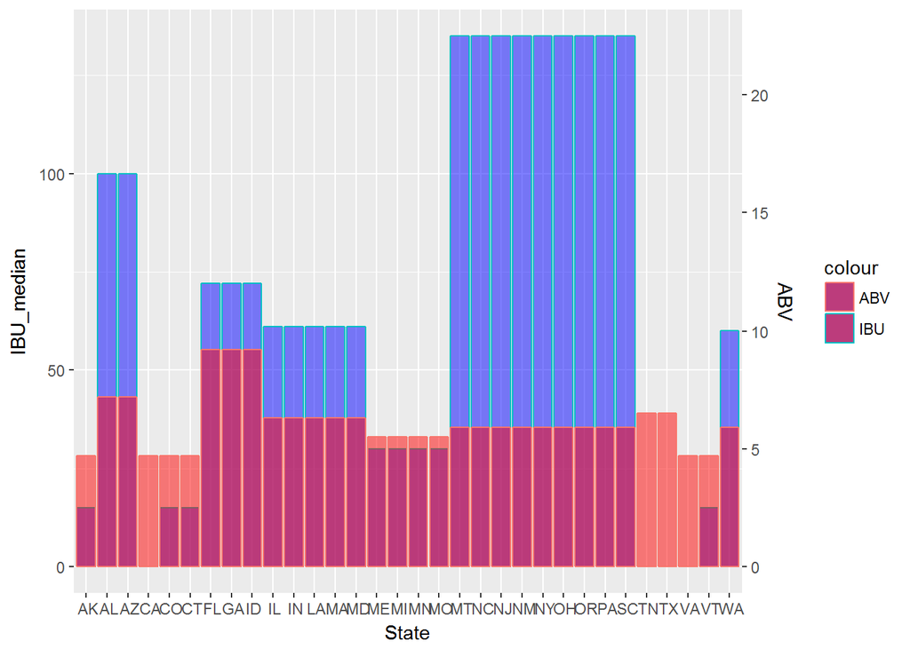

```r
library(ggplot2)
##Create a plot with the staes along the x-axis
p <- ggplot2::ggplot(mediansByState, aes(x = State))

##Create and add the y-axis. Also, give it a low alpha value and change it's fill color
p <- p + geom_bar(aes(y = IBU_median, color = "IBU"), stat="identity", alpha = .5 , fill="blue")

##Create and add the second y-axis. Also, give it a low alpha value and change it's fill color
##Note that the extra 100 multiplier is to turn the scale of those data into a percentage scale
p <- p + geom_bar(aes(y = ABV_median*100*6, color = "ABV"), alpha = .5 , fill="red", stat="identity")

##Create the right side second axis and give it the inverse scale used to transform the data
p <- p + scale_y_continuous(sec.axis = sec_axis(~./6, name = "ABV"))

##Display the ggplot and marvel at its splendor
p
```

Upon review of the results we derived from looking at the median alcohol content (ABV), as well as the median bitterness levels (IBU) we are able to confirm that the states with beer offerings with the highest median ABV are Georgia, Florida, and Idaho (with median ABVs of 0.092 respectively) as previously confirmed.

**However the beer with the highest ABV is Lee Hill Series Vol. 5 - Belgian Style Quadrupel Ale (0.128 ABV). This beer is sold in COLORADO.**

```r
beer$State[which.max(beer$ABV)]
```

```
## [1]  CO
## 51 Levels:  AK  AL  AR  AZ  CA  CO  CT  DC  DE  FL  GA  HI  IA  ID ...  WY
```

We are further able to confirm that the states with the highest median bitter beers as measured in IBU’s are NY, OH, NC, OR, PA, NM, MT, SC, and NJ respectively, with each state returning a median IBU score of 135.  
**However, the individual state returning the highest IBU (138)is OREGON (Bitter Bitch Imperial IPA)**

```r
beer$State[which.max(beer$IBU)]
```

```
## [1]  OR
## 51 Levels:  AK  AL  AR  AZ  CA  CO  CT  DC  DE  FL  GA  HI  IA  ID ...  WY
```

```r
summary(beer$ABV)
```

```
##    Min. 1st Qu.  Median    Mean 3rd Qu.    Max.    NA's
## 0.00100 0.05000 0.05600 0.05977 0.06700 0.12800      62
```

*What is the relationship of Alcohol content and Bitterness for MABco’s beer offerings?* The graph below is a scatterplot that examines the relationship between ABV and IBU for each beer that MABco has provided us data on. As you can see there is a direct linear correlation betwen the bitterness of the beer and it’s corresponding alcohol content. As the alcohol content increases, so does the bitterness.

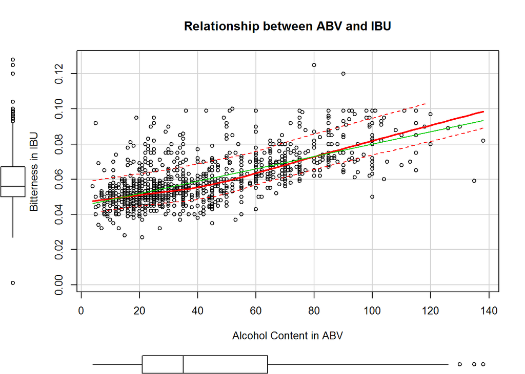

```r
## Scatterplot examining relationship between bitterness and alcohol content ##
## ABV vs. IBU
library(car)
scatterplot(ABV ~ IBU, data=merged,
    xlab="Alcohol Content in ABV", ylab="Bitterness in IBU",
   main="Relationship between ABV and IBU",
   labels=row.names(merged))
```

In summary DBI has provided MABco with a look at it’s brewery presence (by U.S. State), and the results show the top five to be Texas (255), Colorado (253), Indiana (199), Oregon (188), and New York (168). We’ve also provided data regarding the median Alcohol by volume (ABV) by each state. Our findings determined that the states with the highest median (ABV) are Georgia, Florida, and Idaho, each recording a median of 0.092 respectively. We also called out that although these states recorded the highest median values, the state with highest overall ABV from a single beer offering was found outside of this population. Colorado sells the beer with the overall highest ABV offered (Lee Hill Series Vol. 5 - Belgian Style Quadrupel Ale (0.128 ABV)). When examining all beer offerings the overall average (ABV) was found to be 0.05977. Further, we provided data regarding the bitterness of MABco’s beer offerings as measured in (IBU), and reported our findings by state. DBI determined that the states with the highest median bitter beers as measured in IBU’s are NY, OH, NC, OR, PA, NM, MT, SC, and NJ respectively, with each state returning a median IBU score of (135 IBU). When measuring (IBU) overall maximum’s we found that the individual state returning the highest IBU (138) was Oregon (Bitter Bitch Imperial IPA). Please note the state with the maximum bitterness value does reside in the highest median population we examined (unlike the ABV findings). Lastly, we provided a graphical representation outlining the relationship between the Alcohol by Volume (ABV) and the bitterness (IBU) of each of MABco’s beer offerings. The graph clearly outlined a positive linear relationship between the variables. In general, as the ABV increased, so did the bitterness levels as recorded by IBU. Further evaluation can be conducted here with MABco’s direction if more detailed analysis is needed regarding the noted correlation.

This concludes our analysis.